# SARFRAZ_HW5

Hussain Sarfraz

10/5/2021

## Question 1

#### Part 1: Setting the Working Directory

To start off I needed to install the **read.xl** library to access the **us_avg_tuition.xlsx** file.

After I did that I needed to establish my working directory by writing down my file path of where my data is saved. I set my file path through the **setwd()** function and then created the **tuition_dataset** object which stored the **us_avg_tuition.xlsx** dataset.

After I completed these steps I successfully set the working directory to access files in the **DATA 101** folder which is in my desktop. I could now access the dataset that I wanted to which is **us_avg_tuition.xlsx**.

```r
library(readxl)
setwd("C:/Users/hussainsarfraz/Desktop/DATA 101/Week 5 - Importing and Tidying Datasets")
tuition_dataset <-  read_xlsx('us_avg_tuition.xlsx')
```

#### Part 2: Tidying the Data

After getting access to the dataset I needed to tidy the data just so it can be easier to work with. I first wanted to understand and view the data better so I viewed it through the **view()** function. I am displaying the first 4 rows of the dataset to show what I was looking at.

```r
tuition_dataset %>%
  head(4)
```

```
## # A tibble: 4 x 13
##   State    `2004` `2005` `2006` `2007` `2008` `2009` `2010` `2011` `2012` `2013`
##   <chr>     <dbl>  <dbl>  <dbl>  <dbl>  <dbl>  <dbl>  <dbl>  <dbl>  <dbl>  <dbl>
## 1 Alabama   5683.  5841.  5753.  6008.  6475.  7189.  8071.  8452.  9098.  9359.
## 2 Alaska    4328.  4633.  4919.  5070.  5075.  5455.  5759.  5762.  6026.  6012.
## 3 Arizona   5138.  5416.  5481.  5682.  6058.  7263.  8840.  9967. 10134. 10296.
## 4 Arkansas  5772.  6082.  6232.  6415.  6417.  6627.  6901.  7029.  7287.  7408.
## # ... with 2 more variables: 2014 <dbl>, 2015 <dbl>
```

After I looked at this dataset I realized that every year was in its own column. The years were supposed to be in one column since it is one variable. Because of this I decided to use the function **pivot_longer()** to place all the years into one column. This is what I did in the code below.

**c()** was used to tell R which values in the first row of the un-tidyed dataset were needed to convert to a column.

**names_to** was the name of the new column that I was going to make (in this case it was year).

**values_to** was the name of the values that were below the first row in the un-tidyed dataset (in this example I am referring to all the values that were below the row year).

```r
tuition_tidy <- tuition_dataset %>%
  pivot_longer(c('2004':'2015'),
               names_to = "Year",
               values_to = "Average_Tuition")

view(tuition_tidy)
```

Now after I tidyed the dataset I was ready to move on to the next question.

**NOTE**: I created a object called **tuition_tidy** and this was used to store the tidy dataset that I have. I will use this object in many instances to analyze the tuition costs across the states.

## Question 2

Now for this question I created a object called **tuition_bystate**. This object would store the dataset of average tuition in each state.

I used **group_by(State)** to group all states together. Doing this would help me calculate the average tuition in each state and I do this through the **summarize** function and calculating the **mean** of the average tuition. I then arrange all the values through the **arrange()** function and use **desc()** to arrange them from highest to lowest order.

```r
tuition_bystate <- tuition_tidy %>%
  group_by(State) %>%
  summarize(state_ave_tuition = mean(Average_Tuition)) %>%
  arrange(desc(state_ave_tuition))
```

I also wanted to display the dataset to see if there are any patterns I can see.

```r
tuition_bystate %>%
  head(5)
```

```
## # A tibble: 5 x 2
##   State         state_ave_tuition
##   <chr>                     <dbl>
## 1 Vermont                  13067.
## 2 New Hampshire            12781.
## 3 New Jersey               12054.
## 4 Pennsylvania             11970.
## 5 Illinois                 11228.
```

The top five states with the highest tuition averages were:

1. Vermont
2. New Hampshire
3. New Jersey
4. Pennsylvania
5. Illinois

When I looked at these five states on the map I notices that all of these states were on the north-east end of America (except for Illinois that was more towards the middle or northern side). But overall, each state was relativity close geographically. This data could suggest that schools in the northern-eastern side on the states have a high cost as compared to schools in other parts of America.

## Question 3

I used the **tuition_bystate** object that I defined in question 2 because is contained the dataset of tuition averages by state. I resized the title, x-axis and y-axis so the labels can be readable and understood.

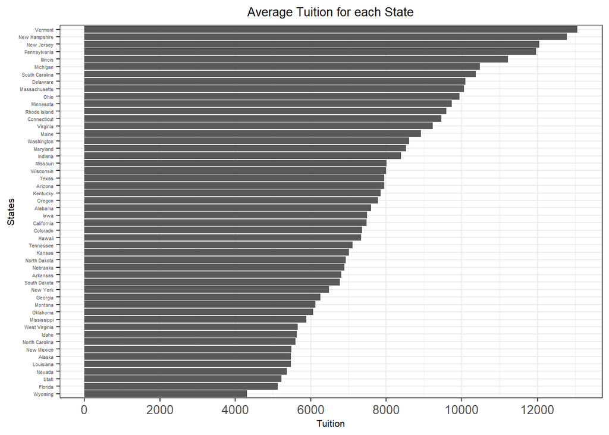

```r
tuition_bystate %>%
  ggplot(mapping = aes(reorder(State,
                               state_ave_tuition), state_ave_tuition)) +
  geom_bar(stat='identity') +
  coord_flip() +
  xlab("States") +
  ylab("Tuition") +
  scale_y_continuous(breaks=c(0,2000,4000,6000,8000,10000,12000)) +
  ggtitle("Average Tuition for each State") +
  theme_bw() +
  theme(plot.title = element_text(hjust = 0.5)) +
  theme(axis.text.x = element_text(size = 10),
        axis.text.y = element_text(size = 4),
        axis.title.x = element_text(size = 8),
        axis.title.y = element_text(size = 8),
        plot.title = element_text(size = 10))
```

## Question 4

I am using the **tuition_tidy** dataset in this question since I need to access the tuition cost for each state from 2015 and 2004 to find the percentage decrease/increase in average tuition cost for each state.

I created the object **percent_avetuition** to store the bar chart of the Percent change of Average Tuition Cost. I am going the compare this bar chart with another bar chart that I will create in part A.

The states with the highest tuition increases are:

1. Hawaii
2. Colorado
3. Arizona
4. Georgia
5. Nevada

The states with the lowest tuition increases are:

1. Ohio
2. Maryland
3. Montana
4. Missouri
5. Iowa

```r
percent_avetuition <- tuition_tidy %>%
  filter(Year == 2004 | Year == 2015) %>%
  group_by(State) %>%
  summarise(percent_avedecrease=(last(Average_Tuition)-first(Average_Tuition))/first(Average_Tuition)) %>%
  ggplot(mapping = aes(reorder(State,
                               percent_avedecrease), percent_avedecrease)) +
  geom_bar(stat='identity') +
  coord_flip() +
  xlab("States") +
  ylab("Percentage") +
  ggtitle("Percent change of Average Tuition Cost") +
  theme_bw() +
  theme(plot.title = element_text(hjust = 0.5)) +
  theme(axis.text.x = element_text(size = 10),
        axis.text.y = element_text(size = 4),
        axis.title.x = element_text(size = 8),
        axis.title.y = element_text(size = 8),
        plot.title = element_text(size = 10))
```

### Question 4: Part A

Now I made a second object called **absolute_tuition_change** which displays the Absolute Value change in Tuition.

The states with the highest tuition changes are:

1. Hawaii
2. Arizona
3. Colorado
4. Illinois
5. New Hampshire

The states with the lowest tuition changes are:

1. Ohio
2. Maryland
3. Montana
4. Wyoming
5. Iowa

After comparing this list with the highest and lowest state percentage increases/decreases I have noticed that the list for both categories are similar. **NOTE**: There were were some states that were different and were not on the list so the 2 lists were not entirely identical.

This means that the absolute value change for tuition does relate to the percentages increase/decrease of tuition. Take a look at Ohio. The **percentage change of average tuition cost** was below zero and even the **absolute value change** was below zero also.

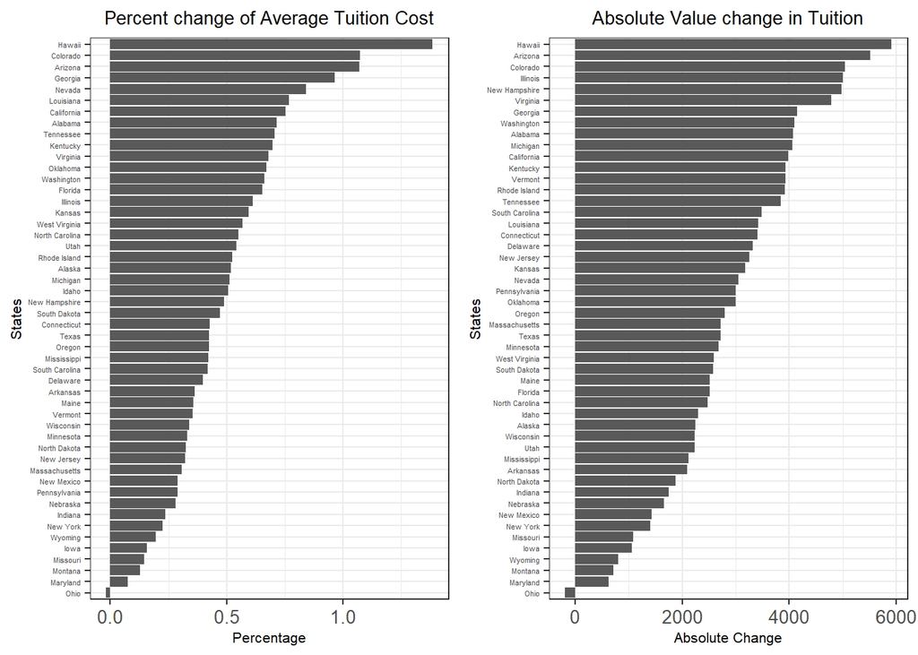

```r
absolute_tuition_change <- tuition_tidy %>%
  filter(Year == 2004 | Year == 2015) %>%
  group_by(State) %>%
  summarise(absolute_change=(last(Average_Tuition)-first(Average_Tuition))) %>%
  ggplot(mapping = aes(reorder(State,
                               absolute_change), absolute_change)) +
  geom_bar(stat='identity') +
  coord_flip() +
  xlab("States") +
  ylab("Absolute Change") +
  ggtitle("Absolute Value change in Tuition") +
  theme_bw() +
  theme(plot.title = element_text(hjust = 0.5)) +
  theme(axis.text.x = element_text(size = 10),
        axis.text.y = element_text(size = 4),
        axis.title.x = element_text(size = 8),
        axis.title.y = element_text(size = 8),
        plot.title = element_text(size = 10))

grid.arrange(percent_avetuition, absolute_tuition_change, ncol=2)
```

## Question 5

Here are the 5 states that I chose:

1. Pennsylvania
2. Ohio
3. Virginia
4. Kentucky
5. New York

I picked these 5 states because they were all close to New York. I have always assumed that New York is a really expensive place which is why I wanted to see how it compares to the other average state tuition fees. Today I will test my New York hypothesis out.

### Question 5: Part A

I have graphed all the average tuition for the 5 states that I picked.

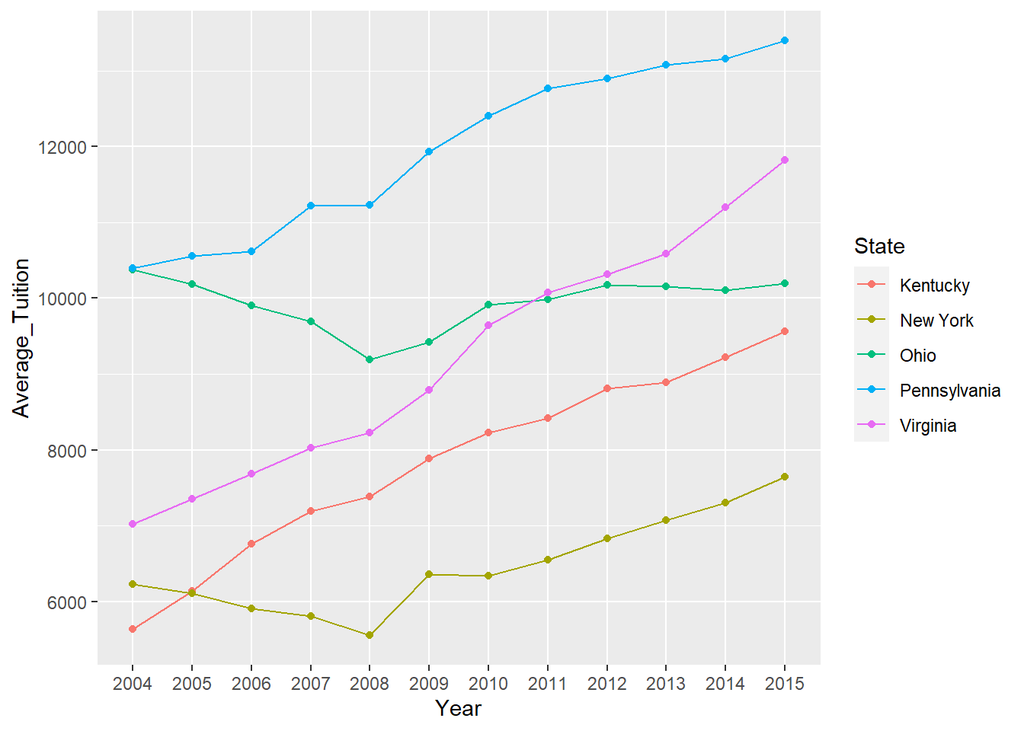

```r
tuition_tidy %>%
  filter(State == "Pennsylvania" | State == "New York" | State == "Ohio" |
         State == "Virginia" | State == "Kentucky") %>%
  ggplot(mapping = aes(x = Year, y = Average_Tuition, color=State, group=State)) +
  geom_line() +
  geom_point()
```

## Bonus Question

The state I choose was New York and I highlighted it in blue. I also want to point out that I have tried many ways to make sure the years on the x-axis were readable but I could not find any formatting option that could help me do that. This is why I removed the years from the x-axis and just included the year range in the name of the x-axis. As mentioned before, I noticed that Vermont has the highest average tuition.

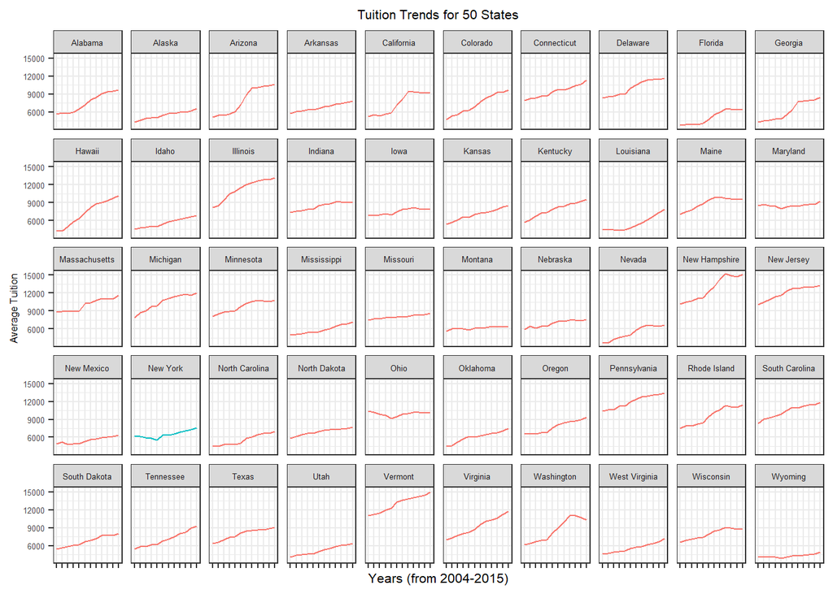

```r
tuition_tidy %>%
  ggplot() +
  geom_line(mapping = aes(x = Year, y = Average_Tuition, group = State,
                          color = ifelse(State == 'New York','#073763','##5e1e42'))) +
  facet_wrap( ~State,nrow=5,) +
  xlab("Years (from 2004-2015)") +
  ylab("Average Tuition") +
  ggtitle("Tuition Trends for 50 States") +
  theme_bw() +
  theme(plot.title = element_text(hjust = 0.5)) +
  theme(plot.title = element_text(size = 8),
        axis.title.x = element_text(size = 8),
        axis.title.y = element_text(size = 6),
        axis.text.x = element_blank(),
        axis.text.y = element_text(size = 5),
        strip.text.x = element_text(size = 5)) +
  theme(legend.position = "none")
```